# Genetic Map Description

# 1/ Introduction

This file is a supplementary data attached with the publication concerning the genetic determinism of **Durum Wheat** to the **Fusarium head blight**. It aims to describe the **genetic map** provided in this paper. The script allowing to build the genetic map is in the folder **1_Partie_Bioinfo**.

Let’s upload this genetic map:

```r
#Watch out, to reproduct analysis, you have to update the path.
map=read.table("/Users/yan/Dropbox/Publi_Fusariose/ANALYSIS_REPRO/DATA/map_avec_posi_physique.txt" , header=T )[,c(1:3)]
colnames(map)=c("chromo_map","marker","position_map")

# number of markers
nmark=nrow(map)
```

This genetic map is composed of **16227 markers**. Putative **physical positions** of markers are available.

Let’s upload the physical positions of genes:

```r
POS1=read.table("/Users/yan/Dropbox/Publi_Fusariose/ANALYSIS_REPRO/DATA/Physical_map_of_EPO_on_BW.txt" , na.string="-" , header=T , dec=".") ; colnames(POS1)=c( "chromo_BW" ,  "contig" ,"position_BW" )
POS2=read.table("/Users/yan/Dropbox/Publi_Fusariose/ANALYSIS_REPRO/DATA/physical_map_of_BW.txt", na.string="-" , header=T , dec=".") ;  colnames(POS2)=c( "chromo_BW" ,  "contig" ,"position_BW" )
POS=rbind(POS1,POS2)
```

Charge some **libraries** that will be useful

```r
library(RColorBrewer)
library(xtable)
library(tidyverse)
library(rmdformats)
```

# 2/ Map description

## Summary table

Basic statistics are computed for **every chromosomes** of the genetic map, then for the **A** and **B genomes**, and finally for the **whole genetic map**. Results are presented in the table below:

```r
#Let's create a function that calculate some basic statistics for a piece of map
my_fun=function(my_map){
    num=nrow(bilan)
    num=num+1
    bilan[num,1]=i
    bilan[num,2]=nrow(my_map)
    bilan[num,3]=max(my_map[,3])
    gaps= sort(my_map[,3])[-1] - sort(my_map[,3])[-length(my_map[,3])]
    bilan[num,4]=mean(gaps)
    bilan[num,5]=max(gaps)
    bilan[num,6]=round(nrow(unique(my_map[,c(1,3)])),0)
    return(bilan)
    }

#Let's apply this function on our map, chromosome by chromosome and for the whole map:

# summary table that we are going to fill
bilan=data.frame(matrix(0,0,6)) ; num=0
colnames(bilan)=c("Chromo","nbr_marker","size_in_cM","average_gap","biggest_gap","nb_uniq_pos")

# apply the function to every chromosome
for(i in levels(map$chromo_map)){
    map_K=map[map$chromo_map==i,]
    bilan=my_fun(map_K)
    }
# then to A and B genomes
for(i in c("A" , "B")){
    map_K=map[substr(map$chromo_map , 2 , 2)==i , ]
    bilan=my_fun(map_K)
    }
# then to the whole map
i="tot"
bilan=my_fun(map)
```

```r
print(xtable(bilan), type = "html", include.rownames = F , comment=FALSE)
```

| Chromo | nbr_marker | size_in_cM | average_gap | biggest_gap | nb_uniq_pos |
| --- | --- | --- | --- | --- | --- |
| 1A | 894.00 | 189.10 | 0.21 | 14.00 | 143.00 |
| 1B | 1435.00 | 193.00 | 0.13 | 10.50 | 167.00 |
| 2A | 1459.00 | 228.50 | 0.16 | 11.90 | 175.00 |
| 2B | 1781.00 | 243.30 | 0.14 | 10.60 | 215.00 |
| 3A | 684.00 | 220.20 | 0.32 | 9.90 | 143.00 |
| 3B | 1259.00 | 248.30 | 0.20 | 14.20 | 202.00 |
| 4A | 1142.00 | 238.30 | 0.21 | 11.20 | 170.00 |
| 4B | 1181.00 | 170.70 | 0.14 | 16.00 | 137.00 |
| 5A | 981.00 | 315.00 | 0.32 | 13.40 | 205.00 |
| 5B | 1366.00 | 283.80 | 0.21 | 12.00 | 204.00 |
| 6A | 816.00 | 185.30 | 0.23 | 5.60 | 149.00 |
| 6B | 1244.00 | 187.00 | 0.15 | 8.20 | 161.00 |
| 7A | 1157.00 | 263.10 | 0.23 | 13.90 | 184.00 |
| 7B | 828.00 | 225.70 | 0.27 | 16.80 | 142.00 |
| A | 7133.00 | 315.00 | 0.04 | 8.40 | 1169.00 |
| B | 9094.00 | 283.80 | 0.03 | 9.10 | 1228.00 |
| tot | 16227.00 | 315.00 | 0.02 | 6.50 | 2397.00 |

This table is saved as a **supplementary material** for the publication.

```r
write.table(bilan, "../../../SUPPORTING_DATA/OR_map_feature.csv", sep=";", quote=F, row.names = F)
```

## Markers distribution (plot)

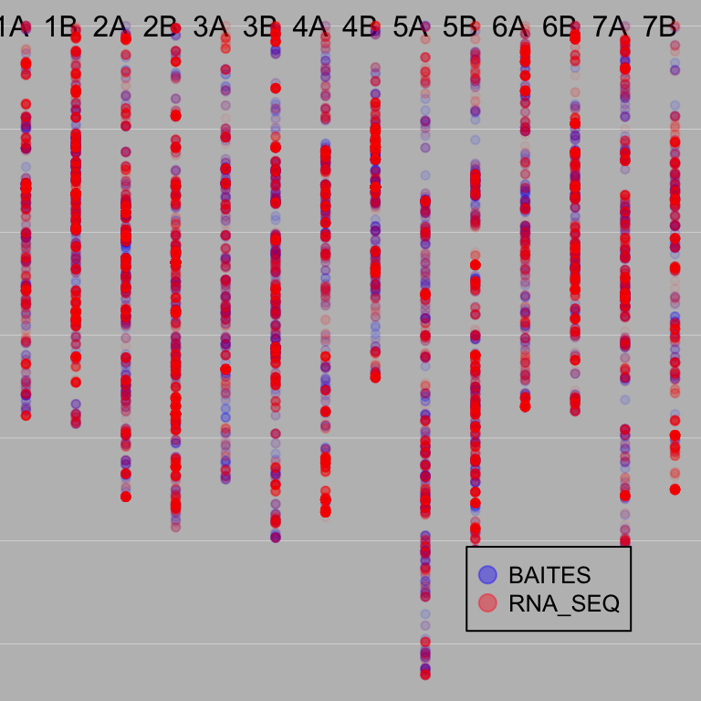

```r
par(mar=c(0,0,0,0))
par(bg="grey")
nb_K=nlevels(map[,1])
num=0
plot(0,0 , xlim=c(1,nb_K) , ylim = rev(range(map[,3])) , bty="n" , xaxt="n" , yaxt="n" )
abline(h=seq(0 , max(map[,3]) , 50) , col="white" , lwd=0.2)
for (i in levels(map[,1])){
    num=num+1
    text(num-0.3 , 0 , i)
    a=map[map[,1]==i , ]
    points( rep(num,nrow(a)) , a[,3]  , pch=20 , cex=1, col=ifelse( regexpr("Traes", a$marker) != -1 | regexpr("TRAES",a$marker) != -1  , rgb(1,0,0,0.05) , rgb(0,0,1,0.1) )  )
    }
legend("bottomright", legend = c("BAITES" , "RNA_SEQ" ) , col = c(rgb(0.1,0.1,1,0.4) , rgb(1,0.1,0.1,0.4)) , bty = 1 , pch=20 , pt.cex = 2, cex = 0.8, horiz = FALSE, inset = c(0.1, 0.1))
```

# 3/ Marey map

For most of the SNPs, a physical position is available trough the Ensembl database. It is interesting to compare the physical and the genetic positions of markers when both informations are available.

## Summary statistics

```r
# First we modify a little the files to be able to merge them. It gives the "data" object:
POS$chromo_BW=as.factor(substr(POS$chromo_BW , 1 , 2))
fun=function(x){strsplit(x,"@")[[1]][1] }
map$contig=unlist(lapply(as.character(map[,2]) , fun))
data=merge(map , POS , by.x=4 , by.y=2 , all=F)
data=data[ , -1]

# Compute the extremity of each chromosomes:
extremity=merge(aggregate(POS$position_BW , by=list(POS$chromo_BW) , min) , aggregate(POS$position_BW , by=list(POS$chromo_BW) , max) , by.x=1 , by.y=1)

# Function that computes statistics for a piece of map
my_fun=function(my_map , i){
  num=nrow(bilan2)
  num=num+1
  bilan2[num,1]=i
  bilan2[num,2]=nrow(my_map)
  bilan2[num,3]=max(my_map[,3])
  gaps= sort(my_map[,3])[-1] - sort(my_map[,3])[-length(my_map[,3])]
  bilan2[num,4]=mean(gaps)
  bilan2[num,5]=max(gaps)
  common_map=merge(map,my_map , by.x=4 , by.y=2 , all=F)
  common_map=common_map[as.character(common_map$chromo_map) == as.character(common_map$chromo_BW) , ]
  bilan2[num,6]=nrow(common_map)
  bilan2[num,7]=round(cor(common_map$position_map , common_map$position_BW , method="spearman"),2)
  return(bilan2)
}

# we will store the results in a "bilan2"" table:
bilan2=data.frame(matrix(0,0,7))
colnames(bilan2)=c("Chromo","nbr marker","size in cM","average gap","biggest gap", "nbr_common_marker" , "Spearman")

# compute statistics for each chromosome separately:
for(i in levels(map$chromo_map)){
  map_K=POS[POS$chromo_BW==i,]
  bilan2=my_fun(map_K,i)
}
# then for A and B genomes:
for(i in c("A" , "B")){
  map_K=POS[substr(POS$chromo_BW , 2 , 2)==i , ]
  bilan2=my_fun(map_K,i)
}
# then for the whole map:
i="tot"
bilan2=my_fun(POS , i)

#Add these informations to the summary of the genetic map:
bilan=merge(bilan, bilan2[,c(1,6,7)] , by.x=1 , by.y=1)
```

```r
print(xtable(bilan), type = "html", include.rownames = F , comment=FALSE)
```

| Chromo | nbr_marker | size_in_cM | average_gap | biggest_gap | nb_uniq_pos | nbr_common_marker | Spearman |
| --- | --- | --- | --- | --- | --- | --- | --- |
| 1A | 894.00 | 189.10 | 0.21 | 14.00 | 143.00 | 626.00 | 0.98 |
| 1B | 1435.00 | 193.00 | 0.13 | 10.50 | 167.00 | 1155.00 | 0.99 |
| 2A | 1459.00 | 228.50 | 0.16 | 11.90 | 175.00 | 1065.00 | 0.77 |
| 2B | 1781.00 | 243.30 | 0.14 | 10.60 | 215.00 | 1368.00 | 0.97 |
| 3A | 684.00 | 220.20 | 0.32 | 9.90 | 143.00 | 389.00 | 0.98 |
| 3B | 1259.00 | 248.30 | 0.20 | 14.20 | 202.00 | 229.00 | 0.94 |
| 4A | 1142.00 | 238.30 | 0.21 | 11.20 | 170.00 | 786.00 | 0.97 |
| 4B | 1181.00 | 170.70 | 0.14 | 16.00 | 137.00 | 981.00 | 0.87 |
| 5A | 981.00 | 315.00 | 0.32 | 13.40 | 205.00 | 551.00 | 0.98 |
| 5B | 1366.00 | 283.80 | 0.21 | 12.00 | 204.00 | 1080.00 | 0.99 |
| 6A | 816.00 | 185.30 | 0.23 | 5.60 | 149.00 | 629.00 | 0.99 |
| 6B | 1244.00 | 187.00 | 0.15 | 8.20 | 161.00 | 800.00 | 0.97 |
| 7A | 1157.00 | 263.10 | 0.23 | 13.90 | 184.00 | 801.00 | 0.99 |
| 7B | 828.00 | 225.70 | 0.27 | 16.80 | 142.00 | 642.00 | 0.99 |
| A | 7133.00 | 315.00 | 0.04 | 8.40 | 1169.00 | 4847.00 | 0.72 |
| B | 9094.00 | 283.80 | 0.03 | 9.10 | 1228.00 | 6255.00 | 0.84 |
| tot | 16227.00 | 315.00 | 0.02 | 6.50 | 2397.00 | 11102.00 | 0.76 |

It is the table number one of the publication, so we save it also:

```r
write.table(x=bilan,file="/Users/yan/Dropbox/Publi_Fusariose/TABLES/table1.csv", quote=F, col.names=NA , row.names=T, sep=";")
```

## Graphic Representation

This is the “marey map” representation. We will produce a figure for the paper with this code.

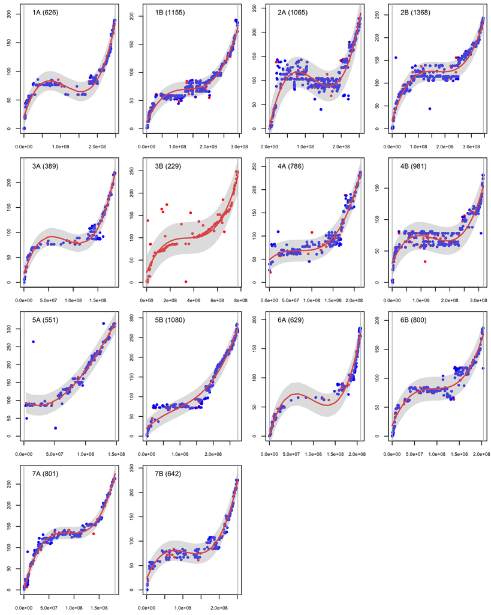

```r
# Plot preparation:
#png(filename = "/Users/yan/Dropbox/Publi_Fusariose/FIGURE/Fig_2.png" )
par(mfrow=c(4,4))
par(mar=c(2.5 , 2.5 , 0.5 , 0.5))

# We will store features of chromosomes in a summary table:
bilan_model=data.frame(matrix(0,14,6) ) ; colnames(bilan_model)=c("chromo" , "a" , "b x" , "c x2", "dx3" , "R2 adj")
bilan_outsider=data[0, ]
bilan_outsider2=data[0, ]
num=0

# For each chromosome:
for(i in levels(data$chromo_map)){

    # Plot each markers with both physical & genetic positions:
    don=data[data$chromo_map==i & data$chromo_BW==i & !is.na(data$chromo_BW) , ]
    if(nrow(don)==0){next}
    my_contigs=unlist(lapply(as.character(don$marker) , fun))
    plot(don$position_map ~ don$position_BW ,  xlab="" , ylab=""  , pch=20 ,
         xlim=c(0,max(don$position_BW , na.rm=T)+20) , ylim=c(0,max(don$position_map , na.rm=T)+20) ,
         col=ifelse( regexpr("Traes", don$marker) != -1 | regexpr("TRAES",don$marker) != -1  , "blue" , "red" ) , cex.axis=0.7)
    legend("topleft", paste(i," (",length(don$position_BW[!is.na(don$position_BW)]),")" , sep="") ,
         cex=1 , text.col="black" , bty="n" )

    # Add 2 ablines for start and end of the chromosome
    abline(v=extremity[extremity[,1]==i ,c(2,3) ] , col="grey")

    # Let's add a polynomial regression:
    num=num+1
    bilan_model[num,1]=i
    y=don$position_map
    x=don$position_BW
    model=lm(y ~ x + I(x^2) + I(x^3))
    bilan_model[num , c(2:5)]=model$coefficients
    bilan_model[num , 6]=summary(model)$adj.r.squared
    myPredict <- predict( model , interval="predict" )
    ix <- sort(x,index.return=T)$ix
    lines(x[ix], myPredict[ix], col=2, lwd=2 )
    polygon(c(rev(x[ix]), x[ix]), c(rev(myPredict[ ix,3]), myPredict[ ix,2]), col = rgb(0.7,0.7,0.7,0.4) , border = NA)

    # Let's notice which are the SNPs far from the polynomial regression (="outsider")
    don$predict=myPredict[,1]
    AA=don[don$predict > don$position_map+15 | don$predict < don$position_map-15 , ]
    bilan_outsider=rbind(bilan_outsider , AA)

    # And notice which one are note in the confidence interval of the regression.
    confidence=    predict( model , interval="predict" )
    don$lwr=confidence[,2]
    don$upr=confidence[,3]
    BB=don[ don$position_map > confidence[,2] & don$position_map > confidence[,3] , ]
    bilan_outsider2=rbind(bilan_outsider2 , BB)

    }
```